# A meta-analysis of the effects of replacing fish meals with insect meals on growth performance of fish - ScienceDirect

## Outline

[figure not shown]

[figure not shown]

[figure not shown]

[figure not shown]

## [Aquaculture](https://www.sciencedirect.com/science/journal/00448486)

[Volume 530](https://www.sciencedirect.com/science/journal/00448486/530/supp/C), 15 January 2021, 735732

# A meta-analysis of the effects of replacing fish meals with insect meals on growth performance of fish

[KathelineHua<sup>a</sup><sup>b</sup>](https://www.sciencedirect.com/science/article/pii/S0044848620315623#!)

## Highlights

**•**

The effects of dietary inclusion levels of insect meals on fish growth performance were quantified through a meta-analysis.

**•**

Fish can utilize moderate levels of insect meals to support growth performance comparable to fish meal-based diet.

**•**

The effects of high levels of insect meals seem to be largely dependent on the insect species.

## Abstract

Recognizing the importance of reducing fish meals in fish feeds to ensure the economic and environmental sustainability of aquaculture operations, there have been growing interests in using insect meals as a protein source in aquaculture feeds. Increasing number of studies have been conducted to test the effects of insect meals as substitutes of fish meals in feeds of various fish species with varying degrees of success. A meta-analysis was carried out to quantify the effects of insect meals on growth performance of fish. The meta-analysis indicated that in general low or moderate dietary incorporation levels of insect meals did not affect the growth of fish in comparison to fish meal-based diets. High dietary inclusion levels of different insect species appeared to have divergent effects on fish growth. While higher than 29% (±3%) dietary inclusion levels of black solider fly meals depressed the growth performance, yellow mealworm seemed to be well tolerated by fish. Full-fat and defatted black soldier fly meals did not seem to differ in their effects on fish growth performance but this should be viewed as inconclusive due to varying degrees of defatting and highly variable nutrient compositions of the insect meals. Overall the results suggest that insect meals are promising novel protein sources for aquaculture feeds. More research is warranted to further elucidate the various influencing factors on the effectiveness of the dietary inclusions of insect meals in aquaculture feeds, as well as to integrate and translate this information into practical feed formulations.

## Keywords

Fish meal

Insect meal

Meta-analysis

Black solider fly

Yellow mealworm

## 1. Introduction

One of the challenges faced by the aquaculture feeds industry is the substitution of fish meals by alternative protein sources due to the concerns about economic and ecological sustainability. There have been growing interests in using insect meals as a protein source in aquaculture feeds to alleviate the pressure from the fish meal usage. Insect meals are considered one of the most promising novel protein sources in aquaculture feeds, not only because of their favorable nutritional compositions especially in respect of protein content and amino acid profile, but also in consideration of the feasibility of increasing production to meet the demand for alternative protein sources in aquaculture feeds in connection with available processing technologies, cost and scalability (Hua et al., 2019).

Increasing number of studies have been carried out to test the effects of incorporating insect meals as substitutes of fish meals in feeds of various fish species. Varying degrees of success have been reported in the literature. While most studies recommended partial replacements of fish meals with insect meals, an increasing number of recent studies reported a successful 100% replacement of fish meal without compromising the growth performance of fish, even for carnivorous fish (Henry et al., 2015; Gasco et al., 2019; Hua et al., 2019; Nogales-Merida et al., 2019). However, the comparison of results from different studies is difficult due to differences in diet formulations, dietary nutrient compositions, insect species, fish species, and rearing conditions, etc. The 100% fish meal replacement level achieved by various insect meals in different studies corresponded to different inclusion rates of the insect meals in diets. For example, black soldier fly meal replaced 100% of fish meal at inclusion rates of 14.75–25% (Lock et al., 2016; Belghit et al., 2019) in diets of Atlantic salmon (*Salmo salar*), whereas the dietary inclusion rates to achieve 100% fish meal replacement were 10.6–14% for Jian carp (*Cyprinus carpio* var. Jian) (Li et al., 2017; Zhou et al., 2018). While a dietary inclusion level of 25% of yellow mealworm was equivalent to a 100% replacement of fish meal for rainbow trout (*Oncorhynchus mykiss*) (Rema et al., 2019), defatted yellow mealworm larvae were included at a dietary inclusion rate of 65% to achieve a 100% fish meal replacement for red seabream (*Pagrus major*) (Ido et al., 2019). It is evident that the fish meal replacement level is not an objective parameter in evaluating nutritive values of alternative ingredients such as insect meals, the same argument put forward by Hua and Bureau (2012) in evaluating plant protein sources. Because of the nature of this parameter, the fish meal replacement level achieved in one study cannot be extrapolated with confidence and thus becomes meaningless. A more meaningful investigation of the effects of insect meals should be based on the inclusion levels of insect meals in the diets. Furthermore, due to the varying degrees of success in incorporating different insect meals at various inclusion levels for a variety of fish species, it is necessary to synthesize the results from different studies, and more importantly to quantify the effects to facilitate the translation of the results into practical feed formulations.

Meta-analysis is a useful approach to extract and integrate information from different studies. This approach has been used to examine the issue of fish meal replacement by several protein sources in fish feeds (Drakeford and Pascoe, 2008; Sales, 2009; Hua and Bureau, 2012; Collins et al., 2013). However, so far this approach has not been applied to insect meals in fish feeds and the reviews on the effects of insect meals in aquaculture feeds have remained to be narrative and qualitative (Henry et al., 2015; Gasco et al., 2019; Hua et al., 2019; Nogales-Merida et al., 2019). There is a need to integrate and synthesize the experimental observations through a quantitative approach.

Therefore, the objectives of the present study were to conduct a meta-analysis to investigate the effects of insect meals replacing fish meals in fish diets on growth performance of fish.

## 2. Materials and methods

### 2.1. Literature search and dataset

The meta-analysis was carried out by following the principles of the Cochrane Handbook for Systematic Reviews of Interventions (Higgins et al., 2019) and the Preferred Reporting Items for Systematic Reviews and Meta-Analyses (PRISMA) Statement (Moher et al., 2009). A systematic search of literature was conducted in ISI WEB OF KNOWLEDGE (1965–2019) and SCOPUS (1970–2019) in December 2019. A combination of search terms and Boolean operators on insect species, fish, diet and growth were used to search Topic in ISI WEB OF KNOWLEDGE and Title-Abstract-Keywords in SCOPUS. The pre-specified criteria for a study to be included in the meta-analysis database were:

**(i)**

A control diet that contained fish meal;

**(ii)**

Experimental diets used insect meals as alternative protein sources for aquaculture fish;

**(iii)**

Studies investigated the effects of insect meals on the growth performance of fish. Specific growth rates (SGR) were either reported or could be calculated from the reported information;

**(iv)**

Fish were fed to satiation or excess to allow fish to achieve their growth potential. Studies were excluded in the case in which fish were fed to fixed rations but the satiation status was not reported.

The mean and standard deviation (SD) of SGR from fish meal control diet and insect meal experimental diet were either extracted or calculated from information reported in each study. The calculation of SGR was according to the following equation:$SGR=lnFBW−lnIBWd×100$where FBW = final body weight, IBW = initial body weight, d = number of days.

Comparisons of treatments in the meta-analysis dataset were expressed as response ratio r, the ratio of parameters in experimental and control groups, which serves a measure of the proportionate change resulting from an experimental manipulation (Hedges et al., 1999; Borenstein et al., 2009). Effect sizes in the meta-analysis were obtained by the natural log-transformation of the response ratio r, the ratio of the mean SGR from the fish fed an insect meal diet to the mean SGR from the fish fed the fish meal control diet (Hedges et al., 1999):$lnr=lnSGRe−lnSGRc$where lnr is the effect size log response ratio, SGRe and SGRc represent the means of the SGRs of the experimental diet and the control diet, respectively.

The meta-analysis was performed in JASP software (version 0.9.2, JASP Team, the Netherlands) using random effects models to account for the variation among the populations of studies. Between-study variance was assessed by I<sup>2</sup> statistics (Higgins et al., 2003). Covariate analysis was carried out to investigate the effects of covariates including insect species, insect meal level, fish dietary habit (carnivorous vs. omnivorous), nutrient balance (whether the experimental diets containing insect meals were formulated to be isonitrogenous and isoenergetic to the fish meal control diets) on treatment effects. A further differentiation of individual fish species was not possible due to the limited number of data for carrying out a meaningful analysis for each fish species. The covariate insect meal level was a continuous variable, while other covariates were categorical variables.

Furthermore, to establish the optimal insect meal inclusion level, the relationships between incorporation levels of insect meal and response ratio r were analyzed by simple linear regressions and the following modified broken-line model (a horizontal line and a straight line with a decreasing slope; adapted from Robbins et al., 1979) in GraphPad Prism (version 7.03, GraphPad Software, San Diego, CA, USA):$Y=L+U×X−R$where Y = response ratio r, X = insect meal incorporation level (% of diet), L = the ordinate of the breakpoint, R = the abscissa of the breakpoint, U *=* the slope of the line for X > R. By definition (X–R) is defined as zero when X < R.

## 3. Results

Fig. 1 illustrates the selection process for the studies that were included in the meta-analysis. The meta-analysis dataset consisted of 33 publications in peer-reviewed journals (Table 1). The most studied insect species was black solider fly (*Hermetia illucens*), accounting for 49% of the data, followed by yellow mealworm (*Tenebrio molitor*) representing 27% of the data, and housefly (*Musca domestica*) accounting for 14% of the data. Other insect species such as chironomids, crickets (*Gryllus bimaculatus*), mopane worms (*Imbrasia belina*) made up the rest of the data. A total of 17 fish species were investigated and 63% of the data were derived from carnivorous fish species. The incorporation levels of insect meals ranged from 0.05 to 75.6% of diets. The response ratio, the ratio of SGRs from insect meal diet and fish meal control diet ranged from 0.38 to 2.19, with 51% of the data showing a response ratio below 1.

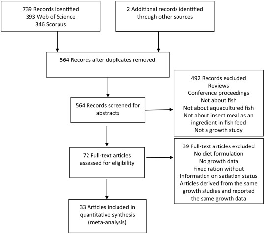

Fig. 1. Selection of studies to be included in the meta-analysis dataset.

Table 1. Source of data in the modelling datasets.

| Authors | Fish species | Insect species | % insect meal inclusion level | Level of fish meal replacement |
| --- | --- | --- | --- | --- |
| Belforti et al., 2015 | Rainbow trout (*Oncorhynchus mykiss*) | *Tenebrio molitor* | 20–50 | Partial |
| Belghit et al., 2018 | Atlantic salmon (*Salmo salar*) | *Hermetia illucens* | 60 | Partial |
| Belghit et al., 2019 | Atlantic salmon (*Salmo salar*) | *Hermetia illucens* | 4.91–14.75 | Partial to total |
| Caimi et al., 2020 | Siberian sturgeon (*Acipenser baerii* Brandt) | *Hermetia illucens* | 18.5–37.5 | Partial |
| Devic et al., 2018 | Nile tilapia (*Oreochromis niloticus*) | *Hermetia illucens* | 3–8 | Partial |
| Dumas et al., 2018 | Rainbow trout (*Oncorhynchus mykiss*) | *Hermetia illucens* | 6.59–26.37 | Partial to total |
| Gasco et al., 2016 | European seabass bass (*Dicentrarchus labrax* L.) | *Tenebrio molitor* | 25–50 | Partial |
| Hashizume et al., 2019 | Red seabream (*Pagrus major*) | *Musca domestica* | 40 | Total |
| Hu et al., 2017 | Yellow catfish (*Pelteobagrus fulvidraco*) | *Hermetia illucens* | 5.6–16.9 | Partial |
| Ido et al., 2015 | Red seabream (*Pagrus major*) | *Musca domestica* | 0.05–5 | Partial |
| Ido et al., 2019 | Red seabream (*Pagrus major*) | *Tenebrio molitor* | 25–65 | Partial to total |
| Khosravi et al., 2018 | Rockfish (*Sebastes schlegeli*) | *Tenebrio molitor* | 8–32 | Partial |
| Kroeckel et al. 2012 | Turbot (*Psetta maxima*) | *Hermetia illucens* | 16.5–75.6 | Partial |
| Li et al., 2017 | Jian carp (*Cyprinus carpio* var. Jian) | *Hermetia illucens* | 2.6–10.6 | Partial to total |
| Lin and Mui, 2017 | Barramundi (*Lates calcarifer*) | *Musca domestica* | 10–30 | Partial |
| Lock et al., 2016 | Atlantic salmon (*Salmo salar*) | *Hermetia illucens* | 5–25 | Partial to total |
| Magalhaes et al., 2017 | European seabass bass (*Dicentrarchus labrax* L.) | *Hermetia illucens* | 6.5–19.5 | Partial |
| Piccolo et al., 2017 | Gilthead seabream (*Sparus aurata*) | *Tenebrio molitor* | 25–50 | Partial |
| Rapatsa and Moyo, 2017 | Mozambique tilapia (*Oreochromis mossambicus*) | *Imbrasia belina* | 4–24 | Partial |
| Rapatsa and Moyo, 2019 | African catfish (*Clarias gariepinus*) | *Imbrasia belina* | 4–24 | Partial |
| Rema et al., 2019 | Rainbow trout (*Oncorhynchus mykiss*) | *Tenebrio molitor* | 5–25 | Partial to total |
| Roncarati et al., 2019 | Gilthead seabream (*Sparus aurata*) | *Chironomids* | 4.5–9 | Partial |
| Sanchez-Muros et al., 2016 | Nile tilapia (*Oreochromis niloticus*) | *Tenebrio molitor* | 21–43 | Partial |
| Sankian et al., 2018 | Mandarin fish (*Siniperca scherzeri*) | *Tenebrio molitor* | 10–30 | Partial |
| Sealey et al., 2011 | Rainbow trout (*Oncorhynchus mykiss*) | *Hermetia illucens* | 16.4–36.24 | Partial |
| Song et al., 2018 | Pearl gentian grouper (*Epinephelus lanceolatus* ♂ x *Epinephelus fuscoguttatus* ♀) | *Tenebrio molitor* | 2.5–12.5 | Partial |
| St-Hilaire et al., 2007 | Rainbow trout (*Oncorhynchus mykiss*) | *Hermetia illucens* | 14.9–29.8 | Partial |
|  |  | *Musca domestica* | 9.2 | Partial |
| Su et al., 2017 | Yellow catfish (*Pelteobagrus fulvidraco*) | *Tenebrio molitor* | 9–27 | Partial |
| Taufek et al., 2016 | African catfish (*Clarias gariepinus*) | *Gryllus bimaculatus* | 30 | Total |
| Wang et al., 2017 | Nile tilapia (*Oreochromis niloticus*) | *Musca domestica* | 11–43 | Partial to total |
| Wang et al., 2019 | Japanese seabass (*Lateolabrax japonicus*) | *Hermetia illucens* | 4.8–19.2 | Partial |
| Xiao et al., 2018 | Yellow catfish (*Pelteobagrus fulvidraco*) | *Hermetia illucens* | 5.5–58.5 | Partial to total |
| Zhou et al., 2018 | Jian carp (*Cyprinus carpio* var. Jian) | *Hermetia illucens* | 3.5–14 | Partial to total |

Fig. 2 presents the forest plot of the treatment effect sizes of insect meals. The meta-analysis showed a mean effect size of −0.03 (confidence interval CI: −0.09 to 0.02, *p* = .208). This translated to a mean growth response of 97% (CI: 91% to 102%) of fish elicited by the insect meal diets and a non-significant difference from the growth response of fish to the fish meal control diets. The test of heterogeneity was significant at *p* < .001 and the I<sup>2</sup> index was 98.73%, indicating significant variances between studies. A further meta-analysis revealed that covariates of insect meal levels and nutrient balance had significant effects (*p* < .001) on the effect size, and there were significant interactions (*p* < .05) between nutrient balance and insect species, as well as between nutrient balance and fish dietary habits. Further analyses were carried out on subgroups of insect species and nutrient balance. Among the insect species, only the groups of black solider fly (*Hermetia illucens*) and yellow mealworm (*Tenebrio molitor*) contained sufficient data to allow subgroup analyses.

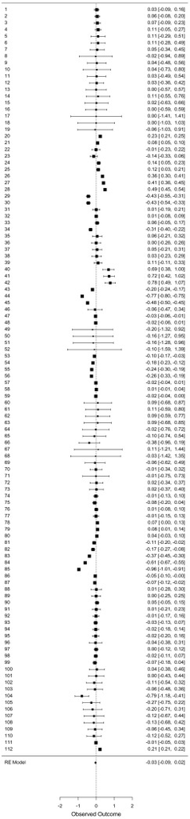

Fig. 2. Forest plot of effect sizes (log response ratio) of experimental diets containing insect meals.

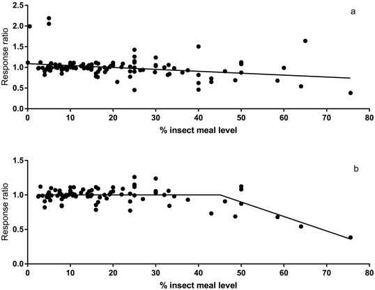

Fig. 3. The relationship between the insect meal inclusion level and the response ratio for the full dataset (3a) and the nutrient balanced dataset (3b).

For the nutrient balanced dataset, the relationship was best described by the broken-line equation (Fig. 3b):$r=1.001−0.021×%insect meal−45.06,R2=0.45,Sy.x=0.10$

The results suggested that when all data were considered, increasing insect meal levels depressed fish growth performance linearly. However, when the experimental diets and the control diets were isonitrogenous and isoenergetic, insect meals at levels below 45% (± 3%) had no negative effect on fish growth performance in comparison to fish meal control diets. However, at levels above this threshold, a significant reduction in growth performance was observed with an increase in insect meal levels.

The black soldier fly *Hermetia illucens* dataset contained 55 data points and the inclusion levels of black soldier fly meals ranged from 2.5 to 75.6% of diet. The results of the meta-analysis showed a significant negative effect of black soldier fly meals (*p* = .007). The mean effect size was −0.09 (CI: −0.16 to −0.02), which translated to a mean response of 91% (CI: 85% to 98%) growth performance of fish fed black soldier fly meals when compared to that of fish fed fish meals.

The relationship between black soldier fly meal incorporation level and the response ratio was best described by a simple negative linear equation (Fig. 4a):$r=1.058−0.006×%black soldierflymeal,R2=0.49,Sy.x=0.11$

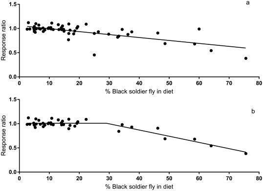

Fig. 4. The relationship between the black soldier fly meal incorporation level and the response ratio was best described by a simple negative linear equation for all data (4a), but by a broken line model when the experimental diets and control diets were balanced for nutrient composition (4b).

However, when the experimental diets and control diets were isonitrogenous and isoenergetic, the broken line model was the best-fit equation to describe the relationship between the black soldier fly meal incorporation level and the response ratio (Fig. 4b):$r=1.01−0.01283×%black soldierflymeal−29.04,R2=0.84,Sy.x=0.06$

The results suggested that when the experimental diets and the control diets were comparable in macronutrient content, black soldier fly meals at levels below 29% (± 3%) had no negative effect on fish growth performance compared to fish meal control diets. However, at levels above this threshold, a significant reduction in growth performance was observed with an increase of black soldier fly meals in diets.

The black soldier fly meals in the nutrient balanced group were further differentiated into full-fat vs. defatted black soldier fly meals. The full-fat and defatted black soldier fly meals accounted for 47% and 53% of the nutrient balanced data, respectively. The broken line model was the best-fit equation for both subgroups to describe the relationship between the incorporation level and the response ratio:$r=1.02−0.01244×%full–fatblack soldierflymeal−33.17,R2=0.66,Sy.x=0.06$$r=0.9997−0.01204×%defatted black soldierflymeal−25.0,R2=0.93,Sy.x=0.05$

The results suggested thresholds of 33% (± 5%) and 25% (± 4%) for full-fat and defatted black soldier fly meals, respectively, beyond which a negative effect on fish growth performance was observed for insect meal diets in comparison to fish meal control diets. The effects of full-fat and defatted black soldier fly meals did not seem to differ.

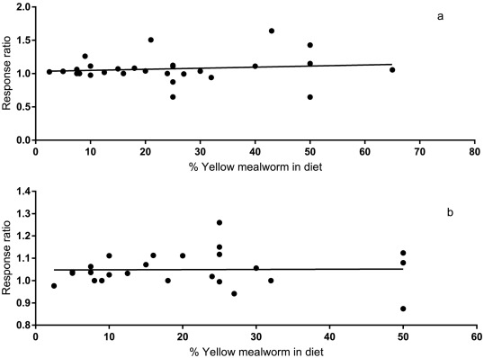

Fig. 5. Linear regression of response ratio on yellow mealworm incorporation level for all data (5a) and nutrient balanced data (5b).

## 4. Discussion

Among the various novel protein sources for aquaculture feeds, insect meals have attracted growing interests and an increasing number of studies on the effects of insect meals have been reported in the literature. While some studies succeeded in a 100% replacement of fish meal with insect meals even for carnivorous fish without compromising fish growth performance, a number of studies observed deleterious effects of high levels of insect meals on growth rates and feed efficiency in fish. The varying degrees of success in replacing fish meal by insect meals were reflected in the wide range of response ratios from 0.38 to 2.19 in the present study. 51% of data in the meta-analysis dataset showed a response ratio below 1, indicating about half of the experimental diets containing insect meals were inferior to fish meal control diets in supporting fish growth performance. In other words, about half the data suggested that insect meals could support similar or even better fish growth performance when compared to fish meal control diets in the literature. The meta-analysis on the full dataset further revealed a mean effect size that was not significant different from zero and a mean growth response that was not significantly different from 100%, which suggested that on average there was no significant difference between the growth performance fish fed insect meals and that of the fish meal control diets.

While the meta-analysis on the full dataset was indicative of the mean effect of insect meals on fish growth performance in the literature and confirmed the usefulness of insect meal in fish feeds, it is obvious that this analysis averaged out the possible influencing factors such as insect species, inclusion levels, dietary nutritional balance, etc. Therefore subgroup analyses were carried out to delineate the effects of these various covariates. An important factor to consider is the inclusion levels of insect meals, which could directly relate to the magnitude of physiological response. Establishing such dose–response relationships or identifying a threshold beyond which negative effects might occur could provide useful information for the optimal incorporation levels of insect meals in practical feed formulation.

The subgroup analysis also revealed differences among specific insect species in their effects on fish growth. High inclusion levels of black soldier fly (above 29 ± 3%) seemed to depress the growth rate of fish when the experimental diets and the control diets were comparable in nutrient content, whereas yellow mealworm in fish diets at any levels did not appear to negatively influence growth rate. On the other hand, there did not seem to be differences between full-fat and defatted black soldier fly meals in their effects on fish growth performance when diets were nutrient balanced. The results strengthened the importance of ensuring the nutritional comparability of the experimental diets when evaluating the nutritive values of insect meals against fish meals.

So far the research on insect meals in aquaculture feeds has mostly focused on black soldier fly, common housefly, and yellow mealworm. Consequently it is likely that the observations of the full dataset were largely influenced by the data from the black soldier fly dataset due to the fact that black soldier fly accounted for nearly half of all data whereas yellow mealworm accounted for about a quarter of the data and common housefly accounted for one seventh of the data. Therefore, the results from the meta-analysis on the full dataset should be treated with caution. The subgroup analysis with different insect species is more meaningful than the generalized results across all insect species.

The differences in the effects between black soldier fly and yellow mealworm worth further investigation and illustrated the importance of identifying the optimal levels for different types of insect meals. In the present study the ranges of the inclusion levels of black soldier fly and yellow mealworm were similar: the inclusion levels of yellow mealworm varied from 2.5 to 65% in experimental diets, whereas the inclusion levels of black soldier fly meals ranged from 2.5 to 75.6% of diet. Therefore, the differences in the effects between these two insect species were likely a reflection of the true differences between the nutritive values of these two insect species rather than an artefact of discrepancies of dietary inclusion levels that were being investigated.

Nutritional values of black soldier flies and yellow mealworms reported in the literature show wide variations in nutrient compositions within insect species and it is thus difficult to compare across species. In general, yellow mealworms seem to contain higher crude protein and lower crude fat levels than black soldier flies. The levels of crude protein in black soldier flies were reported to be 36–59%, whereas the levels were 47–66% in yellow mealworms (Barroso et al., 2014; Makkar et al., 2014; Sanchez-Muros et al., 2014; Marono et al., 2015). Fat levels were reported to be 11–49% in black soldier flies and 15–43% in yellow mealworm (Makkar et al., 2014; Sanchez-Muros et al., 2014; Marono et al., 2015). The nutrient compositions of insect meals are highly dependent on substrates and processing methods. Defatted insect meals can contain up to 83% crude protein and low crude fat (Makkar et al., 2014). For example, defatted yellow mealworms were reported to contain 75% CP and 13% fat (Motte et al., 2019). On the other hand, ash content is usually quite high in black soldier flies in the range of 5 to 28% and rich in Ca and P, whereas yellow mealworms are relatively low in ash in the range of 3 to 6% (Barroso et al., 2014; Makkar et al., 2014; Sanchez-Muros et al., 2014; Marono et al., 2015). If the experimental diets are formulated with insect meals to replace fish meal without balancing nutrient composition across diets, the negative effects of insect meals on fish growth could be due to nutrient deficiencies and thus complicate the assessment and/or the comparison of nutritive values of the insect meals.

Nevertheless, in the subgroup analysis, even when the experimental diets were formulated to be isonitrogenous and isoenergetic to the fish meal control diets, divergent effects between black soldier flies and yellow mealworm at high levels were still found. At low or moderate levels of inclusions, both insect species could elicit growth performance similar to fish meal. This is in agreement with direct experimental data on comparing the effects of these two insect species at low or moderate inclusion levels in Siberian sturgeon and rainbow trout (Józefiak et al., 2019a, Józefiak et al., 2019b). It was observed that 15% or 20% of black soldier fly meal and yellow mealworm meal were able to support comparable growth in Siberian sturgeon and rainbow trout, respectively (Józefiak et al., 2019a, Józefiak et al., 2019b). The divergent effects from these two insect species at high inclusions levels necessitate investigations into factors beyond crude protein content or crude fat content and considerations of other factors that could affect the nutritive values, such as amino acids balance, fatty acids profile, nutrient digestibility, micronutrients and antinutritional factors.

Insect meals may contain high concentrations of non-protein nitrogen. It has been reported that 16–30% of total nitrogen in black soldier fly larvae is non-protein nitrogen (Janssen et al., 2017; Liland et al., 2017), and 12–23% of total nitrogen in mealworms is non-protein nitrogen (Janssen et al., 2017). It is possible that the crude protein levels in some studies were overestimated.

One of the non-protein nitrogen source is chitin. Chitin is a polymer of glucosamine and a nitrogen-containing compound in the cuticle of insects (Barroso et al., 2014; Henry et al., 2015). The effects of chitin from insect meals in fish diets appear to be complex. Chitin is generally considered anti-nutritional, and a compound that fish cannot digest (Rust, 2002). In addition to its negative effect on nutrient digestibility, chitin was also found to depress weight gain and feed conversion in tilapia (Shiau and Yu, 1999). On the other hand, research has demonstrated that low levels of chitin could act as immunostimulants (Henry et al., 2015; Henry et al., 2018b; Henry et al., 2018a). Several studies have observed prebiotic effects of chitin in the modulation of fish gut microbiota (Bruni et al., 2018; Terova et al., 2019).

The observed negative effects of insect meals on fish growth could be partly due to lower digestibility of the nutrients. A number of studies reported that incorporations of insect meals in fish diets could depress nutrient digestibility of the diets when compared to fish meal diets but conflicting results also exist. Belghit et al. (2018) observed lower digestibility of protein, amino acids, fat, and ash in diets containing 60% black soldier fly larvae meal than the fish meal diet in Atlantic salmon and ascribed the lower digestibility to the presence of chitin in black soldier fly larvae meal because chitin may interfere with the intestinal homeostasis in addition to a possible overestimate of crude protein due to non-protein nitrogen. Similarly, reductions in nutrient digestibility were also observed in diets of yellow catfish (*Pelteobagrus fulvidraco*) containing up to 16.9% black soldier fly larvae meal (Hu et al., 2017), and in diets of Siberian sturgeon (*Acipenser baerii* Brandt) juveniles containing 18.5% to 37.5% black soldier fly larvae meal (Caimi et al., 2020). On the other hand, up to 19.5% black soldier fly larvae meal in diets of European seabass (*Dicentrarchus labrax*) did not affect the digestibility of protein, lipid or energy (Magalhaes et al., 2017) and up to 30% black soldier fly larvae meal in diets of rainbow trout did not affect the digestibility of protein and energy (Terova et al., 2019). Renna et al. (2017) observed lower protein digestibility in rainbow trout at the dietary inclusion of 40% black soldier fly but not at 20%, which was attributed to the differences in chitin content from the different levels of insect meals in diets. Conflicting observations also exist for yellow mealworm meals. Dietary inclusions of yellow mealworm meal at 25% and 50% in gilthead sea bream (*Sparus aurata*) resulted in lower apparent digestibility of dry matter, crude protein and energy of the diets (Piccolo et al., 2017). However, Gasco et al. (2016) found that protein digestibility was even higher in diets of European seabass containing 25% yellow mealworm meal than fish meal control diet whereas there was no significant difference in lipid and carbohydrate digestibility, probably due to the presence of chitinase either from the fish or from the intestinal bacteria. Whether the differences in the literature reports were due to differences between black soldier fly larvae meal and yellow mealworm meal or a consequence of the presence/absence of endogenous chitinase among fish species remained to be investigated.

While the above-mentioned studies investigated nutrient digestibility in diets containing different levels of insect meal when comparing to fish meal control diets, studies on apparent digestibility of nutrients in insect meals as single ingredients have also revealed variable results. Protein and essential amino acids in black soldier fly larvae meal were reported to be highly digestible with digestibility values above 84%, whereas lipid was only 43% digestible in rainbow trout (Dumas et al., 2018). Protein and lipid digestibility of black soldier fly larvae meal were found to be 63% and 78%, respectively, in turbot (*Psetta maxima*) (Kroeckel et al., 2012). On the other hand, nutrient digestibility in yellow mealworm seems to be higher. For examples, Fontes et al. (2019) reported digestibility values of 85% and 91% for protein and lipid in yellow mealworm meal for Nile tilapia. A comparative study also found significantly higher nutrient digestibility of yellow mealworm in European sea bass juveniles (Basto et al., 2020). Digestibility values of protein, fat, energy, phosphorus were observed to be 89% and 76%, 95% and 91%, 79% and 67%, 83% and 36% in yellow mealworm meal and black soldier fly meal, respectively. Digestibility of essential amino acids was also higher in yellow mealworm meal (96%) than in black soldier fly meal (92%) (Basto et al., 2020). The chitin content was 4.6% and 6.1%, respectively, in yellow mealworm meal and black soldier fly meal in this comparative study (Basto et al., 2020). There seemed to be a correlation between the chitin content and the differences in nutrient digestibility. However it was also observed in the same study that defatting insect meals in general improved digestibility of nutrients while the chitin content remained similar between defatted and non-defatted insect meals (Basto et al., 2020). It appears that chitin alone cannot explain the lower nutrient digestibility in insect meals. The comparison across studies is complicated by the variable nutrient compositions of insect meals used in specific studies, fish species and experimental conditions and warrants further research.

The amino acid profiles are taxon-dependent and vary with species, with the Diptera group (true flies) demonstrating similar profiles to that of fish meal (Barroso et al., 2014; Henry et al., 2015). The amino acid profiles of black solider flies and yellow mealworms seem to be similar, but one notable difference is the lower methionine concentration in yellow mealworms (Barroso et al., 2014; Makkar et al., 2014; de Marco et al., 2015; Basto et al., 2020). On the other hand, yellow mealworms contain appreciable levels of taurine, which is beneficial for fish growth and health (Henry et al., 2015; Basto et al., 2020). It has been observed that high levels of black solider flies resulted in low taurine concentrations in diets, which might have affected lipid metabolism (Belghit et al., 2018). Amino acids profiles can be improved through processing methods, as found in the defatted insect meals (Basto et al., 2020). However, defatted yellow mealworm meal contained less taurine than non-defatted yellow mealworm meal whereas it was the opposite for black solider flies (Basto et al., 2020). This inconsistency reflects the complexity of assessing nutritive values of ingredients and warrants further research in this area.

Fatty acid profiles of insects are species-specific. The major fatty acid constituents of black soldier fly larvae are saturated fatty acids and monounsaturated fatty acids (Ewald et al., 2020). Medium-chain saturated fatty acid lauric acid (12:0) is the dominant fatty acid in black soldier fly larvae, accounting for between 13% and 52% of total fatty acids (Liland et al., 2017; Oonincx et al., 2015; Ewald et al., 2020). On the other hand, the main fatty acid in yellow mealworms is oleic acid 18:1n9 (Oonincx et al., 2015). In addition yellow mealworms contain higher linoleic acid 18:2n-6 than black soldier fly larvae (Makkar et al., 2014; Oonincx et al., 2015). The levels of long-chain polyunsaturated fatty acids, especially eicosapentaenoic (EPA) and docosahexaenoic (DHA) fatty acids are negligible in all insects (Makkar et al., 2014; Oonincx et al., 2015).

Fatty acid profiles can be manipulated by the substrates used to raise the insects and it is possible to enrich the EPA and DHA content by feeding insects with fish offal or algae (Sealey et al., 2011; Liland et al., 2017; Barroso et al., 2019 ). However, in a recent study with black soldier fly larvae by Ewald et al. (2020), it was observed that the fatty acid profiles can also be affected by the harvesting weight of larvae and the modification of the fatty acid profiles appeared to be limited. Therefore, care should be taken to ensure adequate dietary levels of EPA and DHA to meet the needs of fish. The negative effect of high levels of insect meal on growth performance may arise from the dietary deficiency in EPA and DHA to fish, even though diets are formulated to contain the same levels of dietary lipids as the fish meal control diets. It might be necessary to add fish oils to insect meal based diets to ensure sufficient amounts of EPA and DHA, as demonstrated in a study by Belghit et al. (2018) who successfully incorporated 60% black soldier fly in the diets of Atlantic salmon. Furthermore, the digestibility of lipids is significantly influenced by fatty acid profiles, especially the proportion of saturated, monounsaturated and polyunsaturated fatty acids (Hua and Bureau, 2009). Low lipid digestibility in turbot diets containing high levels of black soldier fly was attributed to the high proportion of saturated fatty acids (Kroeckel et al., 2012). Whether the differences in the effects of high levels of black solider fly meals and yellow mealworms are due to the differences in fatty acid profiles remains to be substantiated.

Meta-analysis is a useful approach to compare and synthesize results from different studies. However, it has limitations in the context of evaluating nutritive values of alternative ingredients replacing fish meal (Hua and Bureau, 2012). The meta-analysis approach is limited by screening data to ensure the comparability of experimental diets and fish meal control diets. Furthermore, comparison across studies should ideally take into account all biological and dietary factors because the issue of fish meal replacement is not a simple matter of using one substance to substitute another (fish meal versus an alternative ingredient). Therefore Hua and Bureau (2012) proposed a nutritional modeling approach as a more robust and flexible approach to assess nutritive values of ingredients. At present the application of this approach in assessing nutritive values of insect meals is impeded by the lack of sufficient information on the composition, digestibility and availability of nutrients from different types of insect meals in various fish species. Also important is a better understanding of the antinutrients and/or immunostimulants in insect meals. Insect meals present special challenges as their nutrient compositions and profiles are highly variable and dependent on substrates, developmental stages of the insects and processing methods. More research is warranted to elucidate the various factors that affect the effectiveness of the dietary inclusions of insect meals in aquaculture feeds and allow a better integration and translation of the knowledge into practical feed formulations.

## 5. Conclusion

With the increasing interests of incorporating insect meals in aquaculture feeds, it is critical to identify their optimal inclusion levels so that fish growth and health can be ensured. The present study employed a meta-analysis approach to quantify the relationship between fish growth performance and the inclusion level of insect meals. The results suggest that in general fish can utilize moderate levels of insect meals in their diets to support growth performance comparable to fish meal-based diets. However, the effects of high levels of insect meals seem to be largely dependent on the species of insects. While high levels of black solider fly depressed fish growth, yellow mealworm seemed to be well tolerated by fish. The results highlighted the importance of future research into the nutritive values of different insect species and the necessity to identify optimal levels for different types of insect meals. The results from this study appear to suggest that a lack of difference between full-fat and defatted black soldier fly meals in their effects on fish growth performance when diets were nutrient balanced. However, these results should be viewed as inconclusive because the delineation of the effects between full-fat and defatted black soldier fly meals is confounded by the varying degrees of defatting (partially or fully defatted meals) and the variable nutrient compositions of the insect meals. The nutrient compositions and profiles of insect meals are highly variable and dependent on substrates, developmental stages of the insects and processing methods of the insect meals. In addition, feed production technologies such as extrusion might play a role in the nutritional values of feeds containing insect meals. Ideally all these influencing factors should be taken into consideration, which was not possible in the present study due to the limited available data. This topic should be revisited later when more research has been carried out in this area. In the meantime, the results stressed the importance of ensuring the nutritional comparability of the experimental diets when evaluating the nutritive values of insect meals against fish meals. Moreover, nutritional models could be a more robust and flexible approach to assess nutritive values of ingredients by integrating various biological and dietary factors. More research is warranted to further elucidate the various factors that affect the effectiveness of the dietary inclusions of insect meal in aquaculture feed, as well as to integrate and translate this information into practical feed formulations.

## Declaration of Competing Interest

The authors declare that they have no known competing financial interests or personal relationships that could have appeared to influence the work reported in this paper.

## Acknowledgements

This research was not supported by any specific grant from funding agencies in the public, commercial, or not-for-profit sectors.

## References

**Barroso et al., 2014**

F.G. Barroso, C. de Haro, M.J. Sanchez-Muros, E. Venegas, A. Martinez-Sanchez, C. Perez-Banon**The potential of various insect species for use as food for fish**

Aquaculture, 422 (2014), pp. 193-201

[Article](https://www.sciencedirect.com/science/article/pii/S0044848613006790)[Download PDF](https://www.sciencedirect.com/science/article/pii/S0044848613006790/pdfft?md5=f8a438bf674f84bb8878b311cf441b5e&pid=1-s2.0-S0044848613006790-main.pdf)[View Record in Scopus](https://www.scopus.com/inward/record.url?eid=2-s2.0-84891954632&partnerID=10&rel=R3.0.0)Google Scholar

**Barroso et al., 2019**

F.G. Barroso, M.J. Sánchez-Muros, M.Á. Rincón, M. Rodriguez-Rodriguez, D. Fabrikov, E. Morote, J.L. Guil-Guerrero**Production of n-3-rich insects by bioaccumulation of fishery waste**

J. Food Compost. Anal., 82 (2019), Article 103237

[Article](https://www.sciencedirect.com/science/article/pii/S0889157518311451)[Download PDF](https://www.sciencedirect.com/science/article/pii/S0889157518311451/pdfft?md5=74e3039c1906e67ca90614470e62d889&pid=1-s2.0-S0889157518311451-main.pdf)Google Scholar

**Basto et al., 2020**

A. Basto, E. Matos, L.M.P. Valente**Nutritional value of different insect larvae meals as protein sources for European sea bass (*Dicentrarchus labrax*) juveniles**

Aquaculture, 521 (2020), p. 735085

[Article](https://www.sciencedirect.com/science/article/pii/S0044848619334532)[Download PDF](https://www.sciencedirect.com/science/article/pii/S0044848619334532/pdfft?md5=b1c80a6fea2207cdf57d9512e58eccb4&pid=1-s2.0-S0044848619334532-main.pdf)[Google Scholar](https://scholar.google.com/scholar?q=Nutritional%20value%20of%20different%20insect%20larvae%20meals%20as%20protein%20sources%20for%20European%20sea%20bass%20%20juveniles)

**Belforti et al., 2015**

M. Belforti, F. Gai, C. Lussiana, M. Renna, V. Malfatto, L. Rotolo, M. De Marco, S. Dabbou, A. Schiavone, I. Zoccarato, L. Gasco*Tenebrio molitor* meal in rainbow trout (*Oncorhynchus mykiss*) diets: effects on animal performance, nutrient digestibility and chemical composition of fillets

Ital. J. Anim. Sci., 14 (2015), p. 4170

[CrossRef](https://doi.org/10.4081/ijas.2015.4170)Google Scholar

**Belghit et al., 2018**

I. Belghit, N.S. Liland, R. Waagbo, I. Biancarosa, N. Pelusio, Y.X. Li, A. Krogdahl, E.J. Lock**Potential of insect-based diets for Atlantic salmon (*Salmo salar*)**

Aquaculture, 491 (2018), pp. 72-81

[Article](https://www.sciencedirect.com/science/article/pii/S0044848617322998)[Download PDF](https://www.sciencedirect.com/science/article/pii/S0044848617322998/pdfft?md5=461dc3cfa6f185c97390baab9b622efe&pid=1-s2.0-S0044848617322998-main.pdf)[View Record in Scopus](https://www.scopus.com/inward/record.url?eid=2-s2.0-85051825922&partnerID=10&rel=R3.0.0)[Google Scholar](https://scholar.google.com/scholar?q=Potential%20of%20insect-based%20diets%20for%20Atlantic%20salmon)

**Belghit et al., 2019**

I. Belghit, N.S. Liland, P. Gjesdal, I. Biancarosa, E. Menchetti, Y.X. Li, R. Waagbo, A. Krogdahl, E.J. Lock**Black soldier fly larvae meal can replace fish meal in diets of sea-water phase Atlantic salmon (*Salmo salar*)**

Aquaculture, 503 (2019), pp. 609-619

[Article](https://www.sciencedirect.com/science/article/pii/S0044848618322208)[Download PDF](https://www.sciencedirect.com/science/article/pii/S0044848618322208/pdfft?md5=709f82954c1842863f5561b2b6bea1ac&pid=1-s2.0-S0044848618322208-main.pdf)[View Record in Scopus](https://www.scopus.com/inward/record.url?eid=2-s2.0-85059624979&partnerID=10&rel=R3.0.0)[Google Scholar](https://scholar.google.com/scholar?q=Black%20soldier%20fly%20larvae%20meal%20can%20replace%20fish%20meal%20in%20diets%20of%20sea-water%20phase%20Atlantic%20salmon)

**Borenstein et al., 2009**

M. Borenstein, L.V. Hedges, J.P.T. Higgins, H.R. Rothstein**Introduction to Meta-Analysis**

Wiley, Amsterdam (2009)

[Google Scholar](https://scholar.google.com/scholar_lookup?title=Introduction%20to%20Meta-Analysis&publication_year=2009&author=M.%20Borenstein&author=L.V.%20Hedges&author=J.P.T.%20Higgins&author=H.R.%20Rothstein)

**Bruni et al., 2018**

L. Bruni, R. Pastorelli, C. Viti, L. Gasco, G. Parisi**Characterisation of the intestinal microbial communities of rainbow trout (*Oncorhynchus mykiss*) fed with *Hermetia illucens* (black soldier fly) partially defatted larva meal as partial dietary protein source**

Aquaculture, 487 (2018), pp. 56-63

[Article](https://www.sciencedirect.com/science/article/pii/S0044848617313662)[Download PDF](https://www.sciencedirect.com/science/article/pii/S0044848617313662/pdfft?md5=c23bcf3baf58700fac06d67eb55493ae&pid=1-s2.0-S0044848617313662-main.pdf)[View Record in Scopus](https://www.scopus.com/inward/record.url?eid=2-s2.0-85042795304&partnerID=10&rel=R3.0.0)Google Scholar

**Caimi et al., 2020**

C. Caimi, M. Renna, C. Lussiana, A. Bonaldo, M. Gariglio, M. Meneguz, S. Dabbou, A. Schiavone, F. Gai, A.C. Elia, M. Prearo, L. Gasco**First insights on Black Soldier fly (*Hermetia illucens* L.) larvae meal dietary administration in Siberian sturgeon (*Acipenser baerii* Brandt) juveniles**

Aquaculture, 515 (2020), p. 734539

[Article](https://www.sciencedirect.com/science/article/pii/S0044848619306131)[Download PDF](https://www.sciencedirect.com/science/article/pii/S0044848619306131/pdfft?md5=1733266378fb9fe4b758a71f2ac5e490&pid=1-s2.0-S0044848619306131-main.pdf)[Google Scholar](https://scholar.google.com/scholar?q=First%20insights%20on%20Black%20Soldier%20fly%20%20larvae%20meal%20dietary%20administration%20in%20Siberian%20sturgeon%20%20juveniles)

**Collins et al., 2013**

S.A. Collins, M. Overland, A. Skrede, M.D. Drew**Effect of plant protein sources on growth rate in salmonids: meta-analysis of dietary inclusion of soybean, pea and canola/rapeseed meals and protein concentrates**

Aquaculture, 400 (2013), pp. 85-100

[Article](https://www.sciencedirect.com/science/article/pii/S0044848613001257)[Download PDF](https://www.sciencedirect.com/science/article/pii/S0044848613001257/pdfft?md5=efa8ed19ebf67bcd3b38a6aa26d20e16&pid=1-s2.0-S0044848613001257-main.pdf)[View Record in Scopus](https://www.scopus.com/inward/record.url?eid=2-s2.0-84875963223&partnerID=10&rel=R3.0.0)Google Scholar

**Devic et al., 2018**

E. Devic, W. Leschen, F. Murray, D.C. Little**Growth performance, feed utilization and body composition of advanced nursing Nile tilapia (*Oreochromis niloticus*) fed diets containing black soldier fly (*Hermetia illucens*) larvae meal**

Aquac. Nutr., 24 (2018), pp. 416-423

[View Record in Scopus](https://www.scopus.com/inward/record.url?eid=2-s2.0-85021235785&partnerID=10&rel=R3.0.0)Google Scholar

**Drakeford and Pascoe, 2008**

B. Drakeford, S. Pascoe**Substitutability of fishmeal and fish oil in diets for salmon and trout: a meta-analysis**

Aquac. Econ. Manag., 12 (2008), pp. 155-175

[CrossRef](https://doi.org/10.1080/13657300802306079)[View Record in Scopus](https://www.scopus.com/inward/record.url?eid=2-s2.0-50349085754&partnerID=10&rel=R3.0.0)Google Scholar

**Dumas et al., 2018**

A. Dumas, T. Raggi, J. Barkhouse, E. Lewis, E. Weltzien**The oil fraction and partially defatted meal of black soldier fly larvae (*Hermetia illucens*) affect differently growth performance, feed efficiency, nutrient deposition, blood glucose and lipid digestibility of rainbow trout (*Oncorhynchus mykiss*)**

Aquaculture, 492 (2018), pp. 24-34

[Article](https://www.sciencedirect.com/science/article/pii/S0044848618300656)[Download PDF](https://www.sciencedirect.com/science/article/pii/S0044848618300656/pdfft?md5=5b8e2282965aedd7f9e9f767ea373e76&pid=1-s2.0-S0044848618300656-main.pdf)[View Record in Scopus](https://www.scopus.com/inward/record.url?eid=2-s2.0-85045044404&partnerID=10&rel=R3.0.0)Google Scholar

**Ewald et al., 2020**

N. Ewald, A. Vidakovic, M. Langeland, A. Kiessling, S. Sampels, C. Lalander**Fatty acid composition of black soldier fly larvae (*Hermetia illucens*) - possibilities and limitations for modification through diet**

Waste Manag., 102 (2020), pp. 40-47

[Article](https://www.sciencedirect.com/science/article/pii/S0956053X19306440)[Download PDF](https://www.sciencedirect.com/science/article/pii/S0956053X19306440/pdfft?md5=841fb2f143b822189482af8c780db98c&pid=1-s2.0-S0956053X19306440-main.pdf)[View Record in Scopus](https://www.scopus.com/inward/record.url?eid=2-s2.0-85073710003&partnerID=10&rel=R3.0.0)[Google Scholar](https://scholar.google.com/scholar?q=Fatty%20acid%20composition%20of%20black%20soldier%20fly%20larvae%20%20-%20possibilities%20and%20limitations%20for%20modification%20through%20diet)

**Fontes et al., 2019**

T.V. Fontes, K.R.B. de Oliveira, I.L.G. Almeida, T.M. Orlando, P.B. Rodrigues, D.V. da Costa, P.V.E. Rosa**Digestibility of insect meals for Nile tilapia fingerlings**

Animals, 9 (2019), p. 181

[CrossRef](https://doi.org/10.3390/ani9040181)Google Scholar

**Gasco et al., 2016**

L. Gasco, M. Henry, G. Piccolo, S. Marono, F. Gai, M. Renna, C. Lussiana, E. Antonopoulou, P. Mola, S. Chatzifotis*Tenebrio molitor* meal in diets for European sea bass (*Dicentrarchus labrax* L.) juveniles: growth performance, whole body composition and in vivo apparent digestibility

Anim. Feed Sci. Technol., 220 (2016), pp. 34-45

[Article](https://www.sciencedirect.com/science/article/pii/S0377840116303297)[Download PDF](https://www.sciencedirect.com/science/article/pii/S0377840116303297/pdfft?md5=47af10d4986e6d866daf2b329b9db400&pid=1-s2.0-S0377840116303297-main.pdf)[View Record in Scopus](https://www.scopus.com/inward/record.url?eid=2-s2.0-84995467750&partnerID=10&rel=R3.0.0)Google Scholar

**Gasco et al., 2019**

L. Gasco, I. Biasato, S. Dabbou, A. Schiavone, F. Gai**Animals fed insect-based diets: state-of-the-art on digestibility, performance and product quality**

Animals, 9 (2019), p. 170

[CrossRef](https://doi.org/10.3390/ani9040170)Google Scholar

**Hashizume et al., 2019**

A. Hashizume, A. Ido, T. Ohta, S.T. Thiaw, R. Morita, M. Nishikawa, T. Takahashi, C. Miura, T. Miura**Housefly (*Musca domestica*) larvae preparations after removing the hydrophobic fraction are effective alternatives to fish meal in aquaculture feed for red seabream (*Pagrus major*)**

Fishes, 4 (2019), p. 38

[CrossRef](https://doi.org/10.3390/fishes4030038)Google Scholar

**Hedges et al., 1999**

L.V. Hedges, J. Gurevitch, P.S. Curtis**The meta-analysis of response ratios in experimental ecology**

Ecology, 80 (1999), pp. 1150-1156

[View Record in Scopus](https://www.scopus.com/inward/record.url?eid=2-s2.0-0033037138&partnerID=10&rel=R3.0.0)[Google Scholar](https://scholar.google.com/scholar_lookup?title=The%20meta-analysis%20of%20response%20ratios%20in%20experimental%20ecology&publication_year=1999&author=L.V.%20Hedges&author=J.%20Gurevitch&author=P.S.%20Curtis)

**Henry et al., 2015**

M. Henry, L. Gasco, G. Piccolo, E. Fountoulaki**Review on the use of insects in the diet of farmed fish: past and future**

Anim. Feed Sci. Technol., 203 (2015), pp. 1-22

[Article](https://www.sciencedirect.com/science/article/pii/S0377840115000802)[Download PDF](https://www.sciencedirect.com/science/article/pii/S0377840115000802/pdfft?md5=e3f95a64f9ba1648e05c48777513e0ed&pid=1-s2.0-S0377840115000802-main.pdf)[View Record in Scopus](https://www.scopus.com/inward/record.url?eid=2-s2.0-84928339785&partnerID=10&rel=R3.0.0)Google Scholar

**Henry et al., 2018a**

M.A. Henry, L. Gasco, S. Chatzifotis, G. Piccolo**Does dietary insect meal affect the fish immune system? The case of mealworm, *Tenebrio molitor* on European sea bass, *Dicentrarchus labrax***

Dev. Comp. Immunol., 81 (2018), pp. 204-209

[Article](https://www.sciencedirect.com/science/article/pii/S0145305X17305682)[Download PDF](https://www.sciencedirect.com/science/article/pii/S0145305X17305682/pdfft?md5=93cc12e036787bf3ccdf440070356481&pid=1-s2.0-S0145305X17305682-main.pdf)[View Record in Scopus](https://www.scopus.com/inward/record.url?eid=2-s2.0-85037664445&partnerID=10&rel=R3.0.0)Google Scholar

**Henry et al., 2018b**

M.A. Henry, F. Gai, P. Enes, A. Perez-Jimenez, L. Gasco**Effect of partial dietary replacement of fishmeal by yellow mealworm (*Tenebrio molitor*) larvae meal on the innate immune response and intestinal antioxidant enzymes of rainbow trout (*Oncorhynchus mykiss*)**

Fish Shellfish Immunol., 83 (2018), pp. 308-313

[Article](https://www.sciencedirect.com/science/article/pii/S1050464818305849)[Download PDF](https://www.sciencedirect.com/science/article/pii/S1050464818305849/pdfft?md5=4e93a61ab7a9e6b05bd250e1ba7571e8&pid=1-s2.0-S1050464818305849-main.pdf)[View Record in Scopus](https://www.scopus.com/inward/record.url?eid=2-s2.0-85053371062&partnerID=10&rel=R3.0.0)Google Scholar

**Higgins et al., 2003**

J.P.T. Higgins, S.G. Thompson, J.J. Deeks, D.G. Altman**Measuring inconsistency in meta-analyses**

Br. Med. J., 327 (2003), pp. 557-560

[CrossRef](https://doi.org/10.1136/bmj.327.7414.557)[View Record in Scopus](https://www.scopus.com/inward/record.url?eid=2-s2.0-0041876133&partnerID=10&rel=R3.0.0)[Google Scholar](https://scholar.google.com/scholar_lookup?title=Measuring%20inconsistency%20in%20meta-analyses&publication_year=2003&author=J.P.T.%20Higgins&author=S.G.%20Thompson&author=J.J.%20Deeks&author=D.G.%20Altman)

**Higgins et al., 2019**

J.P.T. Higgins, J. Thomas, J. Chandler, M. Cumpston, T. Li, M.J. Page, V.A. Welch (Eds.), Cochrane Handbook for Systematic Reviews of Interventions Version 6.0 (updated July 2019), Cochrane (2019)

www.training.cochrane.org/handbook

[Google Scholar](https://scholar.google.com/scholar?q=Cochrane%20Handbook%20for%20Systematic%20Reviews%20of%20Interventions%20Version%206.0)

**Hu et al., 2017**

J.R. Hu, G.X. Wang, Y.H. Huang, Y.P. Sun, F. He, H.X. Zhao, N.N. Li**Effects of substitution of fish meal with black soldier fly (*Hermetia illucens*) larvae meal, in yellow catfish (*Pelteobagrus fulvidraco*) diets**

Isr. J. Aquacult.-Bamid., 69 (2017), p. 1382

[View Record in Scopus](https://www.scopus.com/inward/record.url?eid=2-s2.0-85018268587&partnerID=10&rel=R3.0.0)[Google Scholar](https://scholar.google.com/scholar?q=Effects%20of%20substitution%20of%20fish%20meal%20with%20black%20soldier%20fly%20%20larvae%20meal,%20in%20yellow%20catfish%20%20diets)

**Hua and Bureau, 2009**

K. Hua, D.P. Bureau**Development of a model to estimate digestible lipid content of salmonid fish feeds**

Aquaculture, 286 (2009), pp. 271-276

[Article](https://www.sciencedirect.com/science/article/pii/S0044848608006972)[Download PDF](https://www.sciencedirect.com/science/article/pii/S0044848608006972/pdfft?md5=95301aa05fab7525ab076bd5133daacd&pid=1-s2.0-S0044848608006972-main.pdf)[View Record in Scopus](https://www.scopus.com/inward/record.url?eid=2-s2.0-57149135732&partnerID=10&rel=R3.0.0)Google Scholar

**Hua and Bureau, 2012**

K. Hua, D.P. Bureau**Exploring the possibility of quantifying the effects of plant protein ingredients in fish feeds using meta-analysis and nutritional model simulation-based approaches**

Aquaculture, 356 (2012), pp. 284-301

[Article](https://www.sciencedirect.com/science/article/pii/S004484861200292X)[Download PDF](https://www.sciencedirect.com/science/article/pii/S004484861200292X/pdfft?md5=7b033299bed19edceade191d1ca9b54e&pid=1-s2.0-S004484861200292X-main.pdf)[View Record in Scopus](https://www.scopus.com/inward/record.url?eid=2-s2.0-84863334961&partnerID=10&rel=R3.0.0)Google Scholar

**Hua et al., 2019**

K. Hua, J.M. Cobcroft, A. Cole, K. Condon, D.R. Jerry, A. Mangott, C. Praeger, M.J. Vucko, C. Zeng, K. Zenger, J.M. Strugnell**The future of aquatic protein: implications for protein sources in aquaculture diets**

One Earth, 1 (2019), pp. 316-329

[Article](https://www.sciencedirect.com/science/article/pii/S2590332219301320)[Download PDF](https://www.sciencedirect.com/science/article/pii/S2590332219301320/pdfft?md5=1838d62b32d7257c28113e36cc4f6451&pid=1-s2.0-S2590332219301320-main.pdf)[View Record in Scopus](https://www.scopus.com/inward/record.url?eid=2-s2.0-85083662356&partnerID=10&rel=R3.0.0)Google Scholar

**Ido et al., 2015**

A. Ido, T. Iwai, K. Ito, T. Ohta, T. Mizushige, T. Kishida, C. Miura, T. Miura**Dietary effects of housefly (*Musca domestica*) (Diptera: Muscidae) pupae on the growth performance and the resistance against bacterial pathogen in red sea bream (*Pagrus major*) (Perciformes: Sparidae)**

Appl. Entomol. Zool., 50 (2015), pp. 213-221

[CrossRef](https://doi.org/10.1007/s13355-015-0325-z)[View Record in Scopus](https://www.scopus.com/inward/record.url?eid=2-s2.0-84928791004&partnerID=10&rel=R3.0.0)[Google Scholar](https://scholar.google.com/scholar?q=Dietary%20effects%20of%20housefly%20%20%20pupae%20on%20the%20growth%20performance%20and%20the%20resistance%20against%20bacterial%20pathogen%20in%20red%20sea%20bream)

**Ido et al., 2019**

A. Ido, A. Hashizume, T. Ohta, T. Takahashi, C. Miura, T. Miura**Replacement of fish meal by defatted yellow mealworm (*Tenebrio molitor*) larvae in diet improves growth performance and disease resistance in red seabream (*Pargus major*)**

Animals, 9 (2019), p. 100

[CrossRef](https://doi.org/10.3390/ani9030100)Google Scholar

**Janssen et al., 2017**

R.H. Janssen, J.P. Vincken, L.A.M. van den Broek, V. Fogliano, C.M.M. Lakemond**Nitrogen-to-protein conversion factors for three edible insects: *Tenebrio molitor*, *Alphitobius diaperinus*, and *Hermetia illucens***

J. Agric. Food Chem., 65 (2017), pp. 2275-2278

[CrossRef](https://doi.org/10.1021/acs.jafc.7b00471)[View Record in Scopus](https://www.scopus.com/inward/record.url?eid=2-s2.0-85016139196&partnerID=10&rel=R3.0.0)Google Scholar

**Józefiak et al., 2019a**

A. Józefiak, S. Nogales-Merida, M. Rawski, B. Kieronczyk, J. Mazurkiewicz**Effects of insect diets on the gastrointestinal tract health and growth performance of Siberian sturgeon (*Acipenser baerii* Brandt, 1869)**

BMC Vet. Res., 15 (2019), p. 11

[Google Scholar](https://scholar.google.com/scholar?q=Effects%20of%20insect%20diets%20on%20the%20gastrointestinal%20tract%20health%20and%20growth%20performance%20of%20Siberian%20sturgeon)

**Józefiak et al., 2019b**

A. Józefiak, S. Nogales-Mérida, Z. Mikołajczak, M. Rawski, B. Kierończyk, J. Mazurkiewicz**The utilization of full-fat insect meal in rainbow trout (*Oncorhynchus mykiss*) nutrition: the effects on growth performance, intestinal microbiota and gastro-intestinal tract histomorphology**

Ann. Anim. Sci., 19 (2019), pp. 747-765

[CrossRef](https://doi.org/10.2478/aoas-2019-0020)[View Record in Scopus](https://www.scopus.com/inward/record.url?eid=2-s2.0-85064409462&partnerID=10&rel=R3.0.0)Google Scholar

**Khosravi et al., 2018**

S. Khosravi, E. Kim, Y.S. Lee, S.M. Lee**Dietary inclusion of mealworm (*Tenebrio molitor*) meal as an alternative protein source in practical diets for juvenile rockfish (*Sebastes schlegeli*)**

Entomol. Res., 48 (2018), pp. 214-221

[View Record in Scopus](https://www.scopus.com/inward/record.url?eid=2-s2.0-85047967748&partnerID=10&rel=R3.0.0)[Google Scholar](https://scholar.google.com/scholar?q=Dietary%20inclusion%20of%20mealworm%20%20meal%20as%20an%20alternative%20protein%20source%20in%20practical%20diets%20for%20juvenile%20rockfish)

**Kroeckel et al., 2012**

S. Kroeckel, A.G.E. Harjes, I. Roth, H. Katz, S. Wuertz, A. Susenbeth, C. Schulz**When a turbot catches a fly: Evaluation of a pre-pupae meal of the black soldier fly (*Hermetia illucens*) as fish meal substitute - Growth performance and chitin degradation in juvenile turbot (*Psetta maxima*)**

Aquaculture, 364 (2012), pp. 345-352

[Article](https://www.sciencedirect.com/science/article/pii/S0044848612005224)[Download PDF](https://www.sciencedirect.com/science/article/pii/S0044848612005224/pdfft?md5=5aecdb63a932cb40cc8874b594af38ef&pid=1-s2.0-S0044848612005224-main.pdf)[View Record in Scopus](https://www.scopus.com/inward/record.url?eid=2-s2.0-84866725176&partnerID=10&rel=R3.0.0)Google Scholar

**Li et al., 2017**

S.L. Li, H. Ji, B.X. Zhang, J.S. Zhou, H.B. Yu**Defatted black soldier fly (*Hermetia illucens*) larvae meal in diets for juvenile Jian carp (*Cyprinus carpio* var. Jian): growth performance, antioxidant enzyme activities, digestive enzyme activities, intestine and hepatopancreas histological structure**

Aquaculture, 477 (2017), pp. 62-70

[Article](https://www.sciencedirect.com/science/article/pii/S0044848617304155)[Download PDF](https://www.sciencedirect.com/science/article/pii/S0044848617304155/pdfft?md5=e7fa7c243d4c1bde32603d5fa9dbc335&pid=1-s2.0-S0044848617304155-main.pdf)[View Record in Scopus](https://www.scopus.com/inward/record.url?eid=2-s2.0-85018411484&partnerID=10&rel=R3.0.0)Google Scholar

**Liland et al., 2017**

N.S. Liland, I. Biancarosa, P. Araujo, D. Biemans, C.G. Bruckner, R. Waagbo, B.E. Torstensen, E.J. Lock**Modulation of nutrient composition of black soldier fly (*Hermetia illucens*) larvae by feeding seaweed-enriched media**

PLoS ONE, 12 (2017), p. e0183188

[CrossRef](https://doi.org/10.1371/journal.pone.0183188)[Google Scholar](https://scholar.google.com/scholar?q=Modulation%20of%20nutrient%20composition%20of%20black%20soldier%20fly%20%20larvae%20by%20feeding%20seaweed-enriched%20media)

**Lin and Mui, 2017**

Y.H. Lin, J.J. Mui**Evaluation of dietary inclusion of housefly maggot (*Musca domestica*) meal on growth, fillet composition and physiological responses for barramundi, *Lates calcarifer***

Aquac. Res., 48 (2017), pp. 2478-2485

[CrossRef](https://doi.org/10.1111/are.13085)[View Record in Scopus](https://www.scopus.com/inward/record.url?eid=2-s2.0-84965010950&partnerID=10&rel=R3.0.0)Google Scholar

**Lock et al., 2016**

E.R. Lock, T. Arsiwalla, R. Waagbo**Insect larvae meal as an alternative source of nutrients in the diet of Atlantic salmon (*Salmo salar*) postsmolt**

Aquac. Nutr., 22 (2016), pp. 1202-1213

[CrossRef](https://doi.org/10.1111/anu.12343)[View Record in Scopus](https://www.scopus.com/inward/record.url?eid=2-s2.0-84938863515&partnerID=10&rel=R3.0.0)[Google Scholar](https://scholar.google.com/scholar?q=Insect%20larvae%20meal%20as%20an%20alternative%20source%20of%20nutrients%20in%20the%20diet%20of%20Atlantic%20salmon%20%20postsmolt)

**Magalhaes et al., 2017**

R. Magalhaes, A. Sanchez-Lopez, R.S. Leal, S. Martinez-Llorens, A. Oliva-Telesa, H. Peres**Black soldier fly (*Hermetia illucens*) pre-pupae meal as a fish meal replacement in diets for European seabass (*Dicentrarchus labrax*)**

Aquaculture, 476 (2017), pp. 79-85

[Article](https://www.sciencedirect.com/science/article/pii/S0044848617304556)[Download PDF](https://www.sciencedirect.com/science/article/pii/S0044848617304556/pdfft?md5=9dd14e894dd58693936ae094d7069968&pid=1-s2.0-S0044848617304556-main.pdf)[View Record in Scopus](https://www.scopus.com/inward/record.url?eid=2-s2.0-85018579300&partnerID=10&rel=R3.0.0)[Google Scholar](https://scholar.google.com/scholar?q=Black%20soldier%20fly%20%20pre-pupae%20meal%20as%20a%20fish%20meal%20replacement%20in%20diets%20for%20European%20seabass)

**Makkar et al., 2014**

H.P.S. Makkar, G. Tran, V. Henze, P. Ankers**State-of-the-art on use of insects as animal feed**

Anim. Feed Sci. Technol., 197 (2014), pp. 1-33

[Article](https://www.sciencedirect.com/science/article/pii/S0377840114002326)[Download PDF](https://www.sciencedirect.com/science/article/pii/S0377840114002326/pdfft?md5=5f55bee03d61a75118ddf8cb4023658b&pid=1-s2.0-S0377840114002326-main.pdf)[View Record in Scopus](https://www.scopus.com/inward/record.url?eid=2-s2.0-85027932786&partnerID=10&rel=R3.0.0)Google Scholar

**de Marco et al., 2015**

M. de Marco, S. Martinez, F. Hernandez, J. Madrid, F. Gai, L. Rotolo, M. Belforti, D. Bergero, H. Katz, S. Dabbou, A. Kovitvadhi, I. Zoccarato, L. Gasco, A. Schiavone**Nutritional value of two insect larval meals (*Tenebrio molitor* and *Hermetia illucens*) for broiler chickens: apparent nutrient digestibility, apparent ileal amino acid digestibility and apparent metabolizable energy**

Anim. Feed Sci. Technol., 209 (2015), pp. 211-218

[Article](https://www.sciencedirect.com/science/article/pii/S0377840115300043)[Download PDF](https://www.sciencedirect.com/science/article/pii/S0377840115300043/pdfft?md5=0e17a6ab1c99bac315860c9242ff7eaa&pid=1-s2.0-S0377840115300043-main.pdf)[View Record in Scopus](https://www.scopus.com/inward/record.url?eid=2-s2.0-84952637881&partnerID=10&rel=R3.0.0)Google Scholar

**Marono et al., 2015**

S. Marono, G. Piccolo, R. Loponte, C. Di Meo, Y.A. Attia, A. Nizza, F. Bovera**In vitro crude protein digestibility of *Tenebrio molitor* and *Hermetia illucens* insect meals and its correlation with chemical composition traits**

Ital. J. Anim. Sci., 14 (2015), p. 3889

[CrossRef](https://doi.org/10.4081/ijas.2015.3889)Google Scholar

**Moher et al., 2009**

D. Moher, A. Liberati, J. Tetzlaff, D.G. Altman, The PRISMA Group**Preferred reporting items for systematic reviews and meta-analyses: the PRISMA statement**

PLoS Med., 89 (2009), pp. 873-880

[CrossRef](https://doi.org/10.1093/ptj/89.9.873)[View Record in Scopus](https://www.scopus.com/inward/record.url?eid=2-s2.0-79953769654&partnerID=10&rel=R3.0.0)Google Scholar

**Motte et al., 2019**

C. Motte, A. Rios, T. Lefebvre, H. Do, M. Henry, O. Jintasataporn**Replacing fish meal with defatted insect meal (yellow mealworm *Tenebrio molitor*) improves the growth and immunity of pacific white shrimp (*Litopenaeus vannamei*)**

Animals, 9 (2019), p. 258

[CrossRef](https://doi.org/10.3390/ani9050258)[Google Scholar](https://scholar.google.com/scholar?q=Replacing%20fish%20meal%20with%20defatted%20insect%20meal%20%20improves%20the%20growth%20and%20immunity%20of%20pacific%20white%20shrimp)

**Nogales-Merida et al., 2019**

S. Nogales-Merida, P. Gobbi, D. Jozefiak, J. Mazurkiewicz, K. Dudek, M. Rawski, B. Kieronczyk, A. Jozefiak**Insect meals in fish nutrition**

Rev. Aquac., 11 (2019), pp. 1080-1103

[CrossRef](https://doi.org/10.1111/raq.12281)[View Record in Scopus](https://www.scopus.com/inward/record.url?eid=2-s2.0-85052929237&partnerID=10&rel=R3.0.0)Google Scholar

**Oonincx et al., 2015**

D. Oonincx, S. van Broekhoven, A. van Huis, J.J.A. van Loon**Feed conversion, survival and development, and composition of four insect species on diets composed of food by-products**

PLoS ONE, 10 (2015), p. e0144601

[CrossRef](https://doi.org/10.1371/journal.pone.0144601)Google Scholar

**Piccolo et al., 2017**

G. Piccolo, V. Iaconisi, S. Marono, L. Gasco, R. Loponte, S. Nizza, F. Bovera, G. Parisi**Effect of Tenebrio molitor larvae meal on growth performance, in vivo nutrients digestibility, somatic and marketable indexes of gilthead sea bream (*Sparus aurata*)**

Anim. Feed Sci. Technol., 226 (2017), pp. 12-20

[Article](https://www.sciencedirect.com/science/article/pii/S0377840116304795)[Download PDF](https://www.sciencedirect.com/science/article/pii/S0377840116304795/pdfft?md5=9a6625b624c3372308202053870cc77d&pid=1-s2.0-S0377840116304795-main.pdf)[View Record in Scopus](https://www.scopus.com/inward/record.url?eid=2-s2.0-85017555919&partnerID=10&rel=R3.0.0)Google Scholar

**Rapatsa and Moyo, 2017**

M.M. Rapatsa, N.A.G. Moyo**Evaluation of *Imbrasia belina* meal as a fishmeal substitute in *Oreochromis mossambicus* diets: growth performance, histological analysis and enzyme activity**

Aquacult. Rep., 5 (2017), pp. 18-26

[Article](https://www.sciencedirect.com/science/article/pii/S2352513416300916)[Download PDF](https://www.sciencedirect.com/science/article/pii/S2352513416300916/pdfft?md5=b2dc5416aa788d3f2abd8206db12cebc&pid=1-s2.0-S2352513416300916-main.pdf)[View Record in Scopus](https://www.scopus.com/inward/record.url?eid=2-s2.0-85006992486&partnerID=10&rel=R3.0.0)Google Scholar

**Rapatsa and Moyo, 2019**

M.M. Rapatsa, N.A.G. Moyo**Enzyme activity and histological analysis of *Clarias gariepinus* fed on *Imbrasia belina* meal used for partial replacement of fishmeal**

Fish Physiol. Biochem., 45 (2019), pp. 1309-1320

[CrossRef](https://doi.org/10.1007/s10695-019-00652-3)[View Record in Scopus](https://www.scopus.com/inward/record.url?eid=2-s2.0-85065964342&partnerID=10&rel=R3.0.0)Google Scholar

**Rema et al., 2019**

P. Rema, S. Saravanan, B. Armenjon, C. Motte, J. Dias**Graded incorporation of defatted yellow mealworm (*Tenebrio molitor*) in rainbow trout (*Oncorhynchus mykiss*) diet improves growth performance and nutrient retention**

Animals, 9 (2019), p. 187

[CrossRef](https://doi.org/10.3390/ani9040187)[Google Scholar](https://scholar.google.com/scholar?q=Graded%20incorporation%20of%20defatted%20yellow%20mealworm%20%20in%20rainbow%20trout%20%20diet%20improves%20growth%20performance%20and%20nutrient%20retention)

**Renna et al., 2017**

M. Renna, A. Schiavone, F. Gai, S. Dabbou, C. Lussiana, V. Malfatto, M. Prearo, M.T. Capucchio, I. Biasato, E. Biasibetti, M. De Marco, A. Brugiapaglia, I. Zoccarato, L. Gasco**Evaluation of the suitability of a partially defatted black soldier fly (*Hermetia illucens* L.) larvae meal as ingredient for rainbow trout (*Oncorhynchus mykiss* Walbaum) diets**

J. Anim. Sci. Biotechnol., 8 (2017), p. 57

[Google Scholar](https://scholar.google.com/scholar?q=Evaluation%20of%20the%20suitability%20of%20a%20partially%20defatted%20black%20soldier%20fly%20%20larvae%20meal%20as%20ingredient%20for%20rainbow%20trout%20%20diets)

**Robbins et al., 1979**

K.R. Robbins, H.W. Norton, D.H. Baker**Estimation of nutrient requirements from growth data**

J. Nutr., 109 (1979), pp. 1710-1714

[View Record in Scopus](https://www.scopus.com/inward/record.url?eid=2-s2.0-0018571110&partnerID=10&rel=R3.0.0)[Google Scholar](https://scholar.google.com/scholar_lookup?title=Estimation%20of%20nutrient%20requirements%20from%20growth%20data&publication_year=1979&author=K.R.%20Robbins&author=H.W.%20Norton&author=D.H.%20Baker)

**Roncarati et al., 2019**

A. Roncarati, R. Cappuccinelli, M.C.T. Meligrana, R. Anedda, S. Uzzau, P. Melotti**Growing trial of gilthead sea bream (*Sparus aurata*) juveniles fed on chironomid meal as a partial substitution for fish meal**

Animals, 9 (2019), p. 144

[CrossRef](https://doi.org/10.3390/ani9040144)[Google Scholar](https://scholar.google.com/scholar?q=Growing%20trial%20of%20gilthead%20sea%20bream%20%20juveniles%20fed%20on%20chironomid%20meal%20as%20a%20partial%20substitution%20for%20fish%20meal)

**Rust, 2002**

M.B. Rust**Nutritional physiology**

J.E. Halver, R.W. Hardy (Eds.), Fish Nutrition, The Academic Press, New York, USA (2002), pp. 368-446

[Google Scholar](https://scholar.google.com/scholar_lookup?title=Nutritional%20physiology&publication_year=2002&author=M.B.%20Rust)

**Sales, 2009**

J. Sales**The effect of fish meal replacement by soyabean products on fish growth: a meta-analysis**

Br. J. Nutr., 102 (2009), pp. 1709-1722

[View Record in Scopus](https://www.scopus.com/inward/record.url?eid=2-s2.0-74949097236&partnerID=10&rel=R3.0.0)[Google Scholar](https://scholar.google.com/scholar_lookup?title=The%20effect%20of%20fish%20meal%20replacement%20by%20soyabean%20products%20on%20fish%20growth%3A%20a%20meta-analysis&publication_year=2009&author=J.%20Sales)

**Sanchez-Muros et al., 2014**

M.J. Sanchez-Muros, F.G. Barroso, F. Manzano-Agugliaro**Insect meal as renewable source of food for animal feeding: a review**

J. Clean. Prod., 65 (2014), pp. 16-27

[Article](https://www.sciencedirect.com/science/article/pii/S095965261300841X)[Download PDF](https://www.sciencedirect.com/science/article/pii/S095965261300841X/pdfft?md5=bc31a805e883c085254170aeb0f02885&pid=1-s2.0-S095965261300841X-main.pdf)[View Record in Scopus](https://www.scopus.com/inward/record.url?eid=2-s2.0-84893764778&partnerID=10&rel=R3.0.0)Google Scholar

**Sanchez-Muros et al., 2016**

M.J. Sanchez-Muros, C. De Haro, A. Sanz, C.E. Trenzado, S. Villareces, F.G. Barroso**Nutritional evaluation of *Tenebrio molitor* meal as fishmeal substitute for tilapia (*Oreochromis niloticus*) diet**

Aquac. Nutr., 22 (2016), pp. 943-955

[CrossRef](https://doi.org/10.1111/anu.12313)[View Record in Scopus](https://www.scopus.com/inward/record.url?eid=2-s2.0-84928319026&partnerID=10&rel=R3.0.0)[Google Scholar](https://scholar.google.com/scholar?q=Nutritional%20evaluation%20of%20Tenebrio%20molitor%20meal%20as%20fishmeal%20substitute%20for%20tilapia%20%20diet)

**Sankian et al., 2018**

Z. Sankian, S. Khosravi, Y.O. Kim, S.M. Lee**Effects of dietary inclusion of yellow mealworm (*Tenebrio molitor*) meal on growth performance, feed utilization, body composition, plasma biochemical indices, selected immune parameters and antioxidant enzyme activities of mandarin fish (*Siniperca scherzeri*) juveniles**

Aquaculture, 496 (2018), pp. 79-87

[Article](https://www.sciencedirect.com/science/article/pii/S0044848618302631)[Download PDF](https://www.sciencedirect.com/science/article/pii/S0044848618302631/pdfft?md5=fa4fc6982778c16d006e97531fd22cb3&pid=1-s2.0-S0044848618302631-main.pdf)[View Record in Scopus](https://www.scopus.com/inward/record.url?eid=2-s2.0-85049800168&partnerID=10&rel=R3.0.0)Google Scholar

**Sealey et al., 2011**

W.M. Sealey, T.G. Gaylord, F.T. Barrows, J.K. Tomberlin, M.A. McGuire, C. Ross, S. St-Hilaire**Sensory analysis of rainbow trout, *Oncorhynchus mykiss*, fed enriched black soldier fly prepupae, *Hermetia illucens***

J. World Aquacult. Soc., 42 (2011), pp. 34-45

[CrossRef](https://doi.org/10.1111/j.1749-7345.2010.00441.x)[View Record in Scopus](https://www.scopus.com/inward/record.url?eid=2-s2.0-79551658304&partnerID=10&rel=R3.0.0)Google Scholar

**Shiau and Yu, 1999**

S.Y. Shiau, Y.P. Yu**Dietary supplementation of chitin and chitosan depresses growth in tilapia, *Oreochromis niloticus* x *O-aureus***

Aquaculture, 179 (1999), pp. 439-446

[Article](https://www.sciencedirect.com/science/article/pii/S0044848699001775)[Download PDF](https://www.sciencedirect.com/science/article/pii/S0044848699001775/pdfft?md5=fea0b6bfd645dba7a8af67c80bf76c9f&pid=1-s2.0-S0044848699001775-main.pdf)[View Record in Scopus](https://www.scopus.com/inward/record.url?eid=2-s2.0-0033198218&partnerID=10&rel=R3.0.0)Google Scholar

**Song et al., 2018**

S.G. Song, S.Y. Chi, B.P. Tan, G.L. Liang, B.Q. Lu, X.H. Dong, Q.H. Yang, H.Y. Liu, S. Zhang**Effects of fishmeal replacement by *Tenebrio molitor* meal on growth performance, antioxidant enzyme activities and disease resistance of the juvenile pearl gentian grouper (*Epinephelus lanceolatus* male x *Epinephelus fuscoguttatus* female)**

Aquac. Res., 49 (2018), pp. 2210-2217

[View Record in Scopus](https://www.scopus.com/inward/record.url?eid=2-s2.0-85045198976&partnerID=10&rel=R3.0.0)Google Scholar

**St-Hilaire et al., 2007**

S. St-Hilaire, C. Sheppard, J.K. Tomberlin, S. Irving, L. Newton, M.A. McGuire, E.E. Mosley, R.W. Hardy, W. Sealey**Fly prepupae as a feedstuff for rainbow trout, *Oncorhynchus mykiss***

J. World Aquacult. Soc., 38 (2007), pp. 59-67

[CrossRef](https://doi.org/10.1111/j.1749-7345.2006.00073.x)[View Record in Scopus](https://www.scopus.com/inward/record.url?eid=2-s2.0-33947730276&partnerID=10&rel=R3.0.0)Google Scholar

**Su et al., 2017**

J.Z. Su, Y.L. Gong, S.P. Cao, F. Lu, D. Han, H.K. Liu, J.Y. Jin, Y.X. Yang, X.M. Zhu, S.Q. Xie**Effects of dietary *Tenebrio molitor* meal on the growth performance, immune response and disease resistance of yellow catfish (*Pelteobagrus fulvidraco*)**

Fish Shellfish Immunol., 69 (2017), pp. 59-66

[Article](https://www.sciencedirect.com/science/article/pii/S1050464817304692)[Download PDF](https://www.sciencedirect.com/science/article/pii/S1050464817304692/pdfft?md5=025b1d6826d76059150abb1d7f5506a1&pid=1-s2.0-S1050464817304692-main.pdf)[View Record in Scopus](https://www.scopus.com/inward/record.url?eid=2-s2.0-85027530101&partnerID=10&rel=R3.0.0)[Google Scholar](https://scholar.google.com/scholar?q=Effects%20of%20dietary%20Tenebrio%20molitor%20meal%20on%20the%20growth%20performance,%20immune%20response%20and%20disease%20resistance%20of%20yellow%20catfish)

**Taufek et al., 2016**

N.M. Taufek, H. Muin, A.A. Raji, S.A. Razak, H.M. Yusof, Z. Alias**Apparent digestibility coefficients and amino acid availability of cricket meal*, gryllus bimaculatus*, and fishmeal in African catfish, *Clarias gariepinus*, diet**

J. World Aquacult. Soc., 47 (2016), pp. 798-805

[CrossRef](https://doi.org/10.1111/jwas.12302)[View Record in Scopus](https://www.scopus.com/inward/record.url?eid=2-s2.0-84978700495&partnerID=10&rel=R3.0.0)Google Scholar

**Terova et al., 2019**

G. Terova, S. Rimoldi, C. Ascione, E. Gini, C. Ceccotti, L. Gasco**Rainbow trout (*Oncorhynchus mykiss*) gut microbiota is modulated by insect meal from *Hermetia illucens* prepupae in the diet**

Rev. Fish Biol. Fish., 29 (2019), pp. 465-486

[CrossRef](https://doi.org/10.1007/s11160-019-09558-y)[View Record in Scopus](https://www.scopus.com/inward/record.url?eid=2-s2.0-85064134994&partnerID=10&rel=R3.0.0)[Google Scholar](https://scholar.google.com/scholar?q=Rainbow%20trout%20%20gut%20microbiota%20is%20modulated%20by%20insect%20meal%20from%20Hermetia%20illucens%20prepupae%20in%20the%20diet)

**Wang et al., 2017**

L. Wang, J. Li, J.N. Jin, F. Zhu, M. Roffeis, X.Z. Zhang**A comprehensive evaluation of replacing fishmeal with housefly (*Musca domestica*) maggot meal in the diet of Nile tilapia (*Oreochromis niloticus*): growth performance, flesh quality, innate immunity and water environment**

Aquac. Nutr., 23 (2017), pp. 983-993

[CrossRef](https://doi.org/10.1111/anu.12466)[View Record in Scopus](https://www.scopus.com/inward/record.url?eid=2-s2.0-85015695823&partnerID=10&rel=R3.0.0)Google Scholar

**Wang et al., 2019**

G.X. Wang, K. Peng, J.R. Hu, C.J. Yi, X.Y. Chen, H.M. Wu, Y.H. Huang**Evaluation of defatted black soldier fly (*Hermetia illucens* L.) larvae meal as an alternative protein ingredient for juvenile Japanese seabass (*Lateolabrax japonicus*) diets**

Aquaculture, 507 (2019), pp. 144-154

[Article](https://www.sciencedirect.com/science/article/pii/S0044848618326437)[Download PDF](https://www.sciencedirect.com/science/article/pii/S0044848618326437/pdfft?md5=e8c6df20147de3db46de6b0f8033ae05&pid=1-s2.0-S0044848618326437-main.pdf)[View Record in Scopus](https://www.scopus.com/inward/record.url?eid=2-s2.0-85064162540&partnerID=10&rel=R3.0.0)[Google Scholar](https://scholar.google.com/scholar?q=Evaluation%20of%20defatted%20black%20soldier%20fly%20%20larvae%20meal%20as%20an%20alternative%20protein%20ingredient%20for%20juvenile%20Japanese%20seabass%20%20diets)

**Xiao et al., 2018**

X.P. Xiao, P. Jin, L.Y. Zheng, M.M. Cai, Z.N. Yu, J. Yu, J.B. Zhang**Effects of black soldier fly (*Hermetia illucens*) larvae meal protein as a fishmeal replacement on the growth and immune index of yellow catfish (*Pelteobagrus fulvidraco*)**

Aquac. Res., 49 (2018), pp. 1569-1577

[CrossRef](https://doi.org/10.1111/are.13611)[View Record in Scopus](https://www.scopus.com/inward/record.url?eid=2-s2.0-85040735682&partnerID=10&rel=R3.0.0)[Google Scholar](https://scholar.google.com/scholar?q=Effects%20of%20black%20soldier%20fly%20%20larvae%20meal%20protein%20as%20a%20fishmeal%20replacement%20on%20the%20growth%20and%20immune%20index%20of%20yellow%20catfish)

**Zhou et al., 2018**

J.S. Zhou, S.S. Liu, H. Ji, H.B. Yu**Effect of replacing dietary fish meal with black soldier fly larvae meal on growth and fatty acid composition of Jian carp (*Cyprinus carpio* var. Jian)**

Aquac. Nutr., 24 (2018), pp. 424-433

[CrossRef](https://doi.org/10.1111/anu.12574)[View Record in Scopus](https://www.scopus.com/inward/record.url?eid=2-s2.0-85040648812&partnerID=10&rel=R3.0.0)[Google Scholar](https://scholar.google.com/scholar?q=Effect%20of%20replacing%20dietary%20fish%20meal%20with%20black%20soldier%20fly%20larvae%20meal%20on%20growth%20and%20fatty%20acid%20composition%20of%20Jian%20carp)

© 2020 Elsevier B.V. All rights reserved.